# Statistical Methods for Reliability Data

Chapter 7 - Parametric Likelihood Fitting Concepts: Exponential Distribution

W. Q. Meeker, L. A. Escobar, and J. K. Freels

22 May 2017

# CHAPTER OVERVIEW

## This chapter explains...

- Likelihood for a parametric model using discrete data
- Likelihood for samples containing right and left consored observations
- Use of parametric likelihood as a tool for data analysis and inference about a single population or process
- The use of likelihood and normal-approximation confidence intervals for model parameters and other quantities of interest
- The density approximation to the likelihood for observations reported as exact failures

# 7.1 - INTRODUCTION

## Maximum Likelihood Estimation

- where $f(\underline{x}|\underline{\theta})$ is... >
- The probability (probability density, actually) of... >
- ...observing data $\underline{x}=x_1,...,x_n, \;\;n\in[1,\infty)$... >
- ...from a distribution with density function of the form $f(x|\theta)$
- Is a function of $\underline{x}$ assuming $\underline{\theta}=\theta_{1},\theta_{2},...$ are known
- What data $\underline{x}$ are most likely to be produced by a distribution with parameters $\underline{\theta}$?
- $f(x_i|\underline{\theta})$ is the probability density associated with observation $x_i$
- But, this statement comes with the following assumptions
  1. We know (or at least have specified) a functional form values for $\theta$
  2. We know (or at least have specified) values for $\theta$

$\mathscr{L}(\underline{\theta}|\underline{x})$

- Is a function of $\underline{\theta}$ assuming $\underline{x}=x_{1},...,x_{n}$ has already been observed
- What values of $\underline{\theta}$ are most likely to have produced $\underline{x}$?

## Properties of MLE's

- If the ML regularity conditions are met

$$\sqrt{n}\left(\hat{\theta}_{_{MLE}}-\theta\right)\xrightarrow{L}N\left(0,\mathscr{I}^{-1}_{\theta}\right)$$

- where $\mathscr{I}_{\theta}$ is the Fisher Information matrix evaluated at $\theta$ which is expressed as

$$\mathscr{I}_{\theta}=-E\left[\frac{\partial^2\mathscr{L}(\underline{\theta}|\underline{x})}{\partial\underline{\theta}(\partial\underline{\theta})^T}\right]=-E\left[\frac{\partial^2\mathscr{L}(\underline{\theta}|\underline{x})}{\partial\theta_i\partial\theta_j}\right]$$
- Functions of MLE's are also MLE's and are asymptotocally normally distributed

```
+ We can use the Delta Method to find these asymptotic distributions
```

### Example 7.1 - Time Between $\alpha$-Particle Emissions

## Background

- Berkson investigated the time between $\alpha$-particle emissions from AM-241
- Physics suggests that the interarrival times of the $\alpha$ particles are $iid\; EXP(\theta)$

## Data set

- The data are $10,220$ observed interarrival times (measured in units of $1/5000$ seconds)
  - The times have been "binned" into intervals as shown in Table 7.1
  - To illustrate the effect of sample size, random samples of size $n=20, 200,\;\&\;2000$ were drawn from the original data set, these samples are shown in Table 7.1

## Figure 7.1 & Table 7.1

```r
teachingApps::figure7_1()
```

# 7.2 - PARAMETRIC LIKELIHOOD

## Total likelihood is equal to the joint probability of the data

- Mathematically this means...

$$\mathscr{L}(\underline{\theta}|\underline{x})=\sum_{i=1}^{n}\mathscr{L}_{i}(\underline{\theta}|x_i)=f(\underline{x}|\underline{\theta})=\prod_{i=1}^{n}f(x_{i}|\underline{\theta}),\;\;\text{if}\;x_{i}\; iid$$

- So...what does that mean?
- Ok, let's walk through it...using a real-world example

### Example - Maximum Likelihood...

## Tell Me If You've Heard This One Before...

- Four distributions walk into a bar
  - An exponential
  - A normal
  - A lognormal
  - A Weibull
- Once inside, they observe $4.2564$ and $0.5319$ laying on the floor
  - The exponential says: 'Those are mine, they came from an exponential distribution'
  - The normal says: 'Those are mine, they came from a normal distribution'
  - The lognormal says: 'Those are mine, they came from a lognormal distribution'
  - The Weibull says: 'Those are mine, they came from a Weibull distribution'
- What steps are required to show which distribution is correct?
  1. Determine which Exponential distribution best fits the data
  2. Determine which Normal distribution best fits the data
  3. Determine which Lognormal distribution best fits the data
  4. Determine which Weibull distribution best fits the data
  5. Determine which of these best-fit distributions best fits the data
- We could perform each of these steps analytically, but...
  - That would be painful and time-consuming
  - It would be of little benefit, since few real problems can be solved analytically
  - I really don't want to
  - Instead, we'll find MLE's for the exponential distribution analytically and find them numerically for the others

## The Exponential distribution

[output not shown]

$$\hat{\theta}_{_{MLE}}=\frac{\sum_{i=1}^n t_i}{n}$$

[output not shown]

$$\hat{\theta}_{_{MLE}}=\frac{4.2564+0.5319}{2}=2.3942$$

[output not shown]

$$\begin{aligned}
\prod_{i=1}^2 f(t_i|\theta=2.3942)&=\left(\frac{1}{2.3942}\right)\exp\left[-\frac{4.2564}{2.3942}\right]\times\left(\frac{1}{2.3942}\right)\exp\left[-\frac{0.5319}{2.3942}\right]\\\\
&=\mathbf{0.0236}
\end{aligned}$$

- To summarize - we determined (analytically) that...
  - The member of the exponential distribution family that best-fits the data $(4.2564, 0.5319)$ was the member for which $\theta=2.3942$
  - The joint probability/likelihood of this model is $0.0236$
  - The value $0.0236$ represents the best that the exponential distribution can do to model this data and will be used to compare with the other distributions
- The graphical solution
  - The plot below shows the joint prabability/likelihood of the exponential distribution to model the observations $(4.2564, 0.5319)$ for various values of $\hat{\theta}$
  - The vertical line shows the value of $\hat{\theta}_{_{MLE}}$ that we computed analytically correndonds to the value of $\theta$ that maximizes the joint probability on the plot
  - It should be clear that graphical solutions can be faster and easier than analytical solutions, but they can also be less accurate

```r
teachingApps::exp_mle()
```

[output not shown]

- The numerical solution
  - Remember the goal of maximum likelihood estimation is to maximize the likelihood function
  - The most straight-forward way to do this is through numerical optimization
  - Numerical optimization can be as fast as graphical methods and as accurate as analytical methods
  - R has [several functions](https://afit.shinyapps.io/r-intro-stats) for optimizing/maximizing functions
  - Here, we'll use my favorite - `nlminb( )`

```r
teachingApps::exp_numerical()
```

## The normal, lognormal, and Weibull distributions

- Each of these distributions have two parameters
- Analytic solutions for find MLE's do not exist for all two-parameter distributions
- Graphical approaches for two-parameter distributions result in three dimensional likelihood surfaces - can be difficult to interpret
- Numerical techniques are preferred and are often required to find the MLE's for distributions with 2 or more unknown parameters
- The shiny app below shows the likelihood surfaces and the numerical solutions for each of these three distributions

```r
teachingApps::soln_numerical()
```

# 7.2.2 - Likelihood Function and Its Maximum

## Every Observation Contributes to the Likelihood Function

- The value of the likelihood function $\mathscr{L}(\underline{\theta}|\underline{x})$ depends on
  1. The assumed parametric model
  2. The observed data
- The total likelihood is comprised of the contributions from every observation
  - For observation $x_i$, the model with the highest probability provides the greatest contribution to the total likelihood
  - For a single observation, the model providing the greatest contribution to the total likelihood may not be the correct model
  - As the number of observatons is increased, more information is obtained and it becomes easier to differentiate which model best-fits the data
- The shiny app below shows how increasing the number of observations makes it easier to tell which model best-fits a data set

```r
teachingApps::maximum_likelihood()
```

## Contributions to the Likelihood Function For Reliability Data

- For failure-time data, observations make one of four contributions to the likelihood function

$$\mathscr{L}_{i}(\underline{\theta}|t_{i})=\begin{cases} S(t_{i}) &\mbox{for a right censored observation}\\\\F(t_{i}) &\mbox{for a left censored observation}\\\\F(t_{i})-F(t_{i-1}) &\mbox{for an interval censored observation}\\\\\lim\limits_{\Delta_i\rightarrow 0} \frac{(F(t_{i})-\Delta_{i})-F(t_{i})}{\Delta_{i}} &\mbox{for an "exact" observations}\end{cases}$$

- Thus, from Eq 2.14, the total likelihood function may be expressed as

$$\begin{aligned}
\mathscr{L}(\underline{\theta}|\underline{x})&=C\prod_{i=1}^{n} \mathscr{L}_{i}(\underline{\theta}|x_i)\\
&=C\prod_{i=1}^{m+1}[F(t_{i})]^{l_{i}}[F(t_{i})-F(t_{i-1})]^{d_{i}}[1-F(t_{i})]^{r_{i}}
\end{aligned}$$

- where
  - $l_i=1$ if $t_i$ is a left censored observation (0 otherwise)
  - $d_i=1$ if $t_i$ is an interval censored observation (0 otherwise)
  - $r_i=1$ if $t_i$ is a right censored observation (0 otherwise)
  - $n = \sum_{j=1}^{m+1}(l_{j}+d_{j}+r_{j})$

# 7.2.3 - Comparison of $\alpha$-Particle Data Analyses

### Example 7.3 - Likelihood for the $\alpha$ Particle Data

## Background

- Berkson modeled the times between $\alpha$-particle arrivals using an $EXP(\theta)$ distribution.
- This example demonstrates the effect of sample size on the value of $\hat{\theta}_{_{MLE}}$

## Data Set

- The original data set contained $10,220$ observations binned into $m+1=8$ time intervals
- The random samples of size $n = 20, 200, 2000$ that were generated from the original data are shown below
- Note that all four of these data sets are available in the `SMRD` package and may be called using
  - `berkson20`
  - `berkson200`
  - `berkson2000`
  - `berkson10200`

```r
data <- matrix(c(3,7,4,1,3,2,0,0,
                 41,44,24,32,29,21,9,0,
                 292,494,332,236,261,308,73,4,
                 1609,2424,1770,1306,1213,1528,354,16),
               nrow  = 4,
               byrow = TRUE)

rownames(data) <- c("n = 20","n = 200","n = 2000","n = 10220")
```

```
          [,1] [,2] [,3] [,4] [,5] [,6] [,7] [,8]
n = 20       3    7    4    1    3    2    0    0
n = 200     41   44   24   32   29   21    9    0
n = 2000   292  494  332  236  261  308   73    4
n = 10220 1609 2424 1770 1306 1213 1528  354   16
```

## Additional Information

- Regardless of which sample size we wish to use, the form of the likelihood function will be the same
- The form of the likelihood function would change if
  - We chose to model the data with a distribution other than the exponential
  - We chose to inspect the samples more (less) often - resulting in a higher (lower) number of intervals
- The form of the likelihood function for these data (assuming the exponential distribution is correct) is expressed as

$$\begin{aligned}
\mathscr{L}(\underline{\theta}|\underline{x})&=C\prod_{j=1}^{8}[F(t_{j}|\theta)-F(t_{j-1}|\theta)]^{d_{j}}\\
&=C\prod_{j=1}^{8}\left[1-\exp\left(-\frac{t_{j}}{\theta}\right)-1-\exp\left(-\frac{t_{j-1}}{\theta}\right)\right]^{d_{j}}\\
&=C\prod_{j=1}^{8}\left[\exp\left(-\frac{t_{j-1}}{\theta}\right)-\exp\left(-\frac{t_{j}}{\theta}\right)\right]^{d_{j}}
\end{aligned}$$

- In R, this likelihood function may be assigned shown below
- Where
  - `theta` represents the exponential parameter value $\theta$ the value of which we are looking to find
  - `d` is a vector-valued variable of size $1\times 8$ representing the number of observations in each of the eight time intervals

```r
Like7.3 <- function(theta,d) {

F <- log(exp(   -0/theta)-exp( -100/theta))*d[1]+
     log(exp( -100/theta)-exp( -300/theta))*d[2]+
     log(exp( -300/theta)-exp( -500/theta))*d[3]+
     log(exp( -500/theta)-exp( -700/theta))*d[4]+
     log(exp( -700/theta)-exp(-1000/theta))*d[5]+
     log(exp(-1000/theta)-exp(-2000/theta))*d[6]+
     log(exp(-2000/theta)-exp(-4000/theta))*d[7]+
     log(exp(-4000/theta)-exp( -Inf/theta))*d[8]

return(-F)  ### Remember: we're minimizing the negative of our function
}
```

```r
P.1 <- nlminb(start = 400, obj = Like7.3, d = data[1,], lower = 100, upper = 800)$par
P.2 <- nlminb(start = 400, obj = Like7.3, d = data[2,], lower = 100, upper = 800)$par
P.3 <- nlminb(start = 400, obj = Like7.3, d = data[3,], lower = 100, upper = 800)$par
P.4 <- nlminb(start = 400, obj = Like7.3, d = data[4,], lower = 100, upper = 800)$par

MLE <- data.frame(P.1,P.2,P.3,P.4)

colnames(MLE) <- c("n = 20","n = 200","n = 2000","n = 10220")
rownames(MLE) <- c("MLE")
```

```
      n = 20  n = 200 n = 2000 n = 10220
MLE 440.1711 572.2742 612.7727  596.3443
```

## Figure 7.3 - Exponential MLE Probability Plots

```r
teachingApps::figure7_3()
```

# 7.3 - Confidence Intervals for $\theta$

# 7.3.1 - Likelihood Confidence Interval for $\theta$

## The Relative Likelihood Function $R(\theta)$

- The likelihood function $\mathscr{L}(\underline{\theta}|\underline{x})$ provides a useful method for computing approximate CI's for
  - Parameters
  - Functions of parameters
- We know that $\mathscr{L}(\underline{\theta}|\underline{x})$ attains its maximum value at $\hat{\theta}_{_{MLE}}$
- We also know that for $\theta \ne \hat{\theta}_{_{MLE}}$, $\mathscr{L}(\theta|\underline{x})<\mathscr{L}(\hat{\theta}_{_{MLE}}|\underline{x})$
- By rearranging this relationship, we can define the relative likelihood function as

$$R(\theta)=\frac{\mathscr{L}(\theta|\underline{x})}{\mathscr{L}(\hat{\theta}_{_{MLE}}|\underline{x})} \in (0,1)$$

## Likelihood-Based Confidence Intervals

- An approximate $100(1-\alpha)\%$ CI for $\theta$ is the set of values for which

$$-2\log[R(\theta)]\le \chi^2_{(1-\alpha;df)}$$

- Or, equivalently, the values for which

$$R(\theta)\ge\exp\left[-\chi^2_{(1-\alpha;df)}/2\right]$$

- Where $df$ is equal to the number of unknown parameters
- Note the following equivalence relationship

$$\frac{\mathscr{L}(\theta|\underline{x})}{\mathscr{L}(\hat{\theta}_{_{MLE}}|\underline{x})}=\exp\left[\frac{\log(\mathscr{L}(\theta|\underline{x}))}{\log(\mathscr{L}(\hat{\theta}_{_{MLE}}|\underline{x})})\right]\ne\frac{\log(\mathscr{L}(\theta|\underline{x}))}{\log(\mathscr{L}(\hat{\theta}_{_{MLE}}|\underline{x}))}$$

### Example: Finding Relative-Likelihood Based CI's

## Background

- For the $\alpha$-particle data set $(n=20)$, a $95\%$ CI for $\theta$ may be found using the relative likelihood in two ways
  - Analytically - The Hard Way
  - Numerically - The Easy Way
- This example walk through both processes

## Finding Likelihood Based CI's Analytically

- Step 1: Find $\hat{\theta}_{_{MLE}}$ by maximizing $\mathscr{L}(\theta|\underline{x})$

$$\begin{aligned}
\mathscr{L}(\theta|\underline{x})&=C\prod^{20}_{i=1}\frac{1}{\theta}\exp\left[-\frac{t}{\theta}\right]\\
&=C\prod_{j=1}^{8}\left[\exp\left(-\frac{t_{j-1}}{\theta}\right)-\exp\left(-\frac{t_{j}}{\theta}\right)\right]^{d_{j}}\\
&=C\sum_{j=1}^{8}d_{j}\times \log\left[\exp\left(-\frac{t_{j-1}}{\theta}\right)-\exp\left(-\frac{t_{j}}{\theta}\right)\right]
\end{aligned}$$

- Step 2: Identify the critical values for $R(\theta)$
  - For this example the only unknown parameter is $\theta,\;(df=1)$
  - Therefore, a two-sided $95\%$ CI for $\hat{\theta}_{_{MLE}}$ is all values of $\hat{\theta}$ for which

$$\begin{aligned}
R(\theta)=\frac{\mathscr{L}(\hat{\theta}|\underline{x})}{\mathscr{L}(\hat{\theta}_{_{MLE}}|\underline{x})}&\ge \exp\left[-\chi^{2}_{(1-.05;1)}/2\right]\\
&\ge 0.147
\end{aligned}$$

```r
exp(-qchisq(.95,1)/2)
```

```
[1] 0.1465001
```

- Step 3: Using the critical values of $R(\theta)$, find the associated critical values for $\theta$
  - If $\hat{\theta}_{_{MLE}}$ is known, the value of $\mathscr{L}(\hat{\theta}_{_{MLE}}|\underline{x})$ can easily be found.
  - The critical value for $R(\theta)$ has already been determined
  - Thus, the critical values for $\theta$ may then be found by recursively substituting values in
    $$\mathscr{L}(\theta|\underline{x})\ge R(\theta_c) \times\mathscr{L}(\hat{\theta}_{_{MLE}}|\underline{x})$$
  - For all but the most basic likelihood functions, Step 3 is hard and time consuming
  - Thankfully, computers can do this for us

## Finding The Relative-Likelihood Based CI Numerically

- Plotting $R(\theta) \sim \theta$ gives a normalized profile of $\mathscr{L}(\theta)$ that can be used to compute CI's for $\theta$
- The SMRD package makes this really easy

```r
teachingApps::berkson200_profile()
```

## Figure 7.2 - Relative Likelihood Functions

- Figure 7.2 shows the relative likelihood functions for each of the four samples from the Berkson data
- Note how the shape of the relative likelihood function changes with differing amounts of information
  - What does this mean mathematically?
  - What does this mean conceptually?
  - The text talks about the 'curvature of the likelihood function' Figure 7.2 is graphically showing this
  - We'll discuss this figure more in a later example
- The Shiny app below allows you to interact with Figure 7.2

```r
teachingApps::figure7_2()
```

# 7.3.2 - Confidence Interval - Significance Test Relationship

## Significance Tests (aka hypothesis tests)

- Consider the region of the parameter space that is the mathematical complement to the region enclosed by the confidence interval

Confidence Intervals

- We observe data
- Attempt to fit many distributions
- Find the "most likely" parameters
- Identify the critial values
- Values inside critical values bound our uncertainty on the parameter value

Significance Test

- We observe data
- Assume one distribution is correct
- Test a single parameter value
- Identify the critical values
- Values outside critical values indicate the data is inconsitent with our hypothesis
- The significance test associated with likelihood-based CI's is known as the Likelihood Ratio Test
- In the $\alpha$-particle example, our uncertaintly about the value of $\hat{\theta}_{_{MLE}}$ was expressed as all values of $\theta$ for which

$$R(\theta|\underline{x})\ge\exp\left[-\chi^2_{(1-\alpha;1)}/2\right]$$

- In the likelihood ratio test (LRT)
  - A single value of $\theta$ is hypothesized, denoted by $\theta_{0}$
  - The LRT tests whether the observed data provides sufficient evidence to reject the hypothesized value $\theta_0$ or not

### Example 7.7 LRT for the $\alpha$-Particle Data Set

## Background

- Investigators believe that the true value for $\theta=650 \left(\frac{1}{5000}\;\text{seconds}\right)$
- They wish to use an LRT to test the hypothesis:

$$\begin{aligned}
H_{0}: \theta &= 650\\
H_{1}: \theta &\ne 650
\end{aligned}$$

## Analysis

- For the sample with $n=200$ observations, the LRT critical values for $\alpha=.05$ would be

$$\begin{aligned}
-2\log\left[R(\theta_{0}|\underline{x})\right]&>\chi^2_{(.95,1)}\\
-2\log\left[\frac{\mathscr{L}(\theta_0|\underline{x})}{\mathscr{L}(\hat{\theta}_{_{MLE}}|\underline{x})}\right]&>3.84
\end{aligned}$$

- The value of the test statistic $2.94$ is less that the critical value of $3.84$
- As this value is not in the rejection region, insufficient evidence exists to reject the null hypothesis that $\theta=650$ at the $.05$ significance level.

## Additional Information

- Meeker notes that the sample with $n=2000$ observations does provide sufficient evidence to reject the null hypothesis that $\theta=650$ at the $.05$ significance level
  - How is this possible

# 7.3.3 - Normal Approximation CI for $\theta$

## The Fisher Information Matrix

- A two-sided $100(1-\alpha)\%$ CI for $\theta$ based on the normal approximation is expressed as

$$\left[\underline{\theta},\overline{\theta}\right]=\hat{\theta}\pm z_{(1-\alpha/2)} \hat{se}_{\hat{\theta}}$$

- Where
  - $\hat{\theta}$ is our point estimate for $\theta$ using the available data  
    This quantity is known
  - $z_{(1-\alpha/2)}$ is the quantile value $NOR(p=1-\alpha/2|\mu=0, \sigma=1)$  
    This quantity is known
  - $\hat{se}_{\hat{\theta}}=\sqrt{\widehat{Var}[\theta]}$  
    This term has yet to be determined and will require the most of our efforts
- In general, the variance & covariance values for the parameters are computed from the Fisher Information Matrix expressed as

$$\mathscr{I}_{\theta}=-E\left[\frac{\partial^2\mathscr{L}(\underline{\theta}|\underline{x})}{\partial\theta_i\partial\theta_j}\right]=E\left[\mathcal{I}_{\hat{\theta}}\right]$$

- The Fisher Information Matrix
  - Gives the expected amount of information before any data has been collected
  - Is primarily a theoretical measure
- Once data has been observed the estimated variances & covariances may be computed from the observed information matrix $\mathcal{I}_{\hat{\theta}}$

## Observed Information Matrix

- The observed information matrix is expressed as

$$\mathcal{I}_{\theta}=-\frac{\partial^2\mathscr{L}(\underline{\theta}|\underline{x})}{\partial\theta_i\partial\theta_j}$$

- Recall, the log-likelihood function for the $\alpha$-particle example
  $$\mathcal{L}(\theta|\underline{t})=\sum_{j=1}^8 d_j \log\left[\exp\left(-\frac{t_{j-1}}{\theta}\right)-\exp\left(-\frac{t_j}{\theta}\right)\right]$$
- The first and second derivatives for this log-likelihood function are expressed as

$$\begin{aligned}
\frac{d\mathcal{L}(\theta)}{d\theta}&=\sum_{j=1}^8 d_j\frac{\frac{t_{j-1}}{\theta^2}\exp\left(-\frac{t_{j-1}}{\theta}\right)-\frac{t_{j}}{\theta^2}\exp\left(-\frac{t_{j}}{\theta}\right)}{\exp\left(-\frac{t_{j-1}}{\theta}\right)-\exp\left(-\frac{t_{j}}{\theta}\right)}\\\\\\\\
\frac{d^2\mathcal{L}(\theta)}{d\theta^2}&=\sum_{j=1}^8 d_j\left[\frac{\frac{t_{j-1}}{\theta^2}\exp\left(-\frac{t_{j-1}}{\theta}\right)-\frac{t_{j}}{\theta^2}\exp\left(-\frac{t_{j}}{\theta}\right)}{\exp\left(-\frac{t_{j-1}}{\theta}\right)-\exp\left(-\frac{t_{j}}{\theta}\right)}\right]^2+
\frac{\frac{-2t_{j-1}}{\theta^3}\exp\left(-\frac{t_{j-1}}{\theta}\right)+\frac{t_{j}^4}{\theta^4}\exp\left(-\frac{t_{j}}{\theta}\right)}{\exp\left(-\frac{t_{j-1}}{\theta}\right)-\exp\left(-\frac{t_{j}}{\theta}\right)}
\end{aligned}$$

- The information observed from a data set may be found by substituting any value for $\hat{\theta}$ into $\frac{\partial^2\mathcal{l}(\theta)}{\partial\theta^2}$
- Substituting $\hat{\theta}_{_{MLE}}$ maximizes the observed information and is typically the value of $\theta$ used
- Substituting $\hat{\theta}_{_{MLE}}$ for $\theta$ in $\frac{\partial^2\mathcal{l}(\theta)}{\partial\theta^2}$ gives

$$\mathcal{I}_{\hat{\theta}_{_{MLE}}} = 0.000574$$

- The parameter variance-covariance matrix, denoted by $\Sigma_{\hat{\theta}}$, is found by inverting the observed information matrix

$$\Sigma_{\hat{\theta}_{_{MLE}}}=\left[\mathcal{I}_{\hat{\theta}_{_{MLE}}}\right]^{-1}$$

- For the $\alpha$-particle data set $T\sim EXP(\theta)$, $\mathcal{I}_{\hat{\theta}}$ is a single element matrix
- The inverse of a single-element matrix is found by simply taking reciprocal, thus

$$\Sigma_{\hat{\theta}_{_{MLE}}}=\frac{1}{0.000574}=1742.2$$

### Using R to Compute $\mathcal{I}_{\hat{\theta}_{MLE}}$ Numerically

- Recall, we found $\hat{\theta}_{_{MLE}}$ by defining the likelihood function as

```r
Like7.3<-function(theta,d) {

F<-log(exp(   -0/theta)-exp( -100/theta))*d[1]+
   log(exp( -100/theta)-exp( -300/theta))*d[2]+
   log(exp( -300/theta)-exp( -500/theta))*d[3]+
   log(exp( -500/theta)-exp( -700/theta))*d[4]+
   log(exp( -700/theta)-exp(-1000/theta))*d[5]+
   log(exp(-1000/theta)-exp(-2000/theta))*d[6]+
   log(exp(-2000/theta)-exp(-4000/theta))*d[7]+
   log(exp(-4000/theta)-exp( -Inf/theta))*d[8]

return(-F)      }
```

- We then used the `nlminb` function to compute a value for $\hat{\theta}_{_{MLE}}$ assuming $n=200$

```r
data[2,]
```

```
[1] 41 44 24 32 29 21  9  0
```

```r
nlminb(start = 400,
       obj = Like7.3,
       d = data[2,],
       lower = 100,
       upper = 800)$par
```

```
[1] 572.2742
```

- We could have also used the `optim` function and arrived at the same solution

```r
optim(par = 400,
      fn = Like7.3,
      d = data[2,],
      lower = 100,
      upper = 800,
      method = "L-BFGS-B")$par
```

```
[1] 572.274
```

- Note - `nlminb` is actually a wrapper function for `optim`
- However, `optim` includes an argument to return a numerical estimate of the Observed Information Matrix (known as the Hessian matrix in some contexts)

```r
optim(par = 400,
      fn = Like7.3,
      d = data[2,],
      lower = 100,
      upper = 800,
      method = "L-BFGS-B",
      hessian = TRUE)$hessian
```

```
             [,1]
[1,] 0.0005745164
```

- To compute the the variance-covariance matrix $\Sigma_{\hat{\theta}_{MLE}}$
  - Use `solve()` to invert $\mathcal{I}_{\hat{\theta}_{MLE}}$
  - Take the reciprocal (only for $1\times 1$ matrices)
- Note: the accuracy of this numerical estimate can decrease as the number of unknown parameters increases

### Using R to Compute $\mathcal{I}_{\hat{\theta}_{MLE}}$ Numerically

- The SMRD package makes this really easy

```
                          MLE   Std.Err.  95% Lower  95% Upper
mu                   6.349618  0.0729013   6.206735   6.492502
sigma                1.000000  0.0000000   1.000000   1.000000
Exponential (mean) 572.274307 41.7195399 496.078667 660.173285
```

```
               mu sigma
mu    0.005314599     0
sigma 0.000000000     0
```

- In general, the diagonal elements of $\Sigma_{\hat{\theta}_{_{MLE}}}$ represent the variances of the parameters $\widehat{Var}\left[\hat{\theta_1}\right],\widehat{Var}\left[\hat{\theta_2}\right],...$
- While the off-diagonal elements represent the covariances $\widehat{Cov}\left[\hat{\theta_i}\hat{\theta_j}\right],\; i\ne j$
- For the $\alpha$-particle example $\widehat{Var}\left[\hat{\theta}_{_{MLE}}\right]=1742.2$
- and

$$\widehat{se}\left[\hat{\theta}_{_{MLE}}\right]=\sqrt{\widehat{Var}\left[\hat{\theta}_{_{MLE}}\right]}=\sqrt{1742.2}=41.72$$

## Returning to Eq 7.6

- The $95\%$ confidence bounds for the $\alpha$-particle assuming that

$$\frac{\hat{\theta}-\theta}{\hat{se}_{\hat{\theta}}}\sim NOR(0,1)$$

- can be expressed as

$$\left[\underline{\theta}, \overline{\theta}\right]=572.3\pm 1.960\times 41.72=\left[ 490,653 \right]$$

- where
  - $572.3=\hat{\theta}_{_{MLE}}, n=200$
  - $1.960=\Phi^{-1}_{_{NOR}}(p=1-0.05/2)$
- Recall from Chapter 2 confidence bands computed using the normal approximation...
  - Should work well for large samples $n>30$
  - May give poor results for small samples $n<30$
- An alternative method to compute $100(1-\alpha)\%$ CI's For positive quantities assumes that

$$\frac{\log(\hat{\theta})-\log(\theta)}{\hat{se}_{\log(\hat{\theta})}}\sim NOR(0,1)$$

- This method has been shown to produce better confidence intervals For positive quantities when the sample size is small
- Using this alternative method the upper and lower confidence limits are expressed as

$$\left[\underline{\log(\theta)},\overline{\log(\theta)}\right]=\log(\hat{\theta}) \pm z_{(1-\alpha/2)}\hat{se}_{\log(\hat{\theta})}$$

- These confidence limits may also be expressed as

$$\left[\underline{\theta},\overline{\theta}\right]=\left[\hat{\theta}/w,\hat{\theta}\times w\right]$$

- Look again at the results produced by the SMRD package

```
                          MLE   Std.Err.  95% Lower  95% Upper
mu                   6.349618  0.0729013   6.206735   6.492502
sigma                1.000000  0.0000000   1.000000   1.000000
Exponential (mean) 572.274307 41.7195399 496.078667 660.173285
```

```
               mu sigma
mu    0.005314599     0
sigma 0.000000000     0
```

- Note that $\Sigma_{\hat{\log(\theta)}_{MLE}}$ is returned, not $\Sigma_{\hat{\theta}_{MLE}}$

## Table 7.3 - Comparison of $\alpha$-Particle ML Results

$$\begin{array}{lcccc}
\hline
& n=10220 & n=2000 & n=200 & n=20 \\
\hline
\text{ML estimate } \hat{\theta} & 596.3 & 612.8 & 572.3 & 440.2 \\
\text{Standard error } \hat{se}_{\hat{\theta}} & 6.084 & 14.13 & 41.72 & 101.0 \\
\hline
\text{Approximate }95\% \text{ CI for } \theta & & & & \\
\hline
\text{Based on the likelihood} & [584,608] & [586,641] & [498,662] & [289,713] \\
\text{Based on } Z_{\log(\hat{\theta})}\sim NOR(0,1) & [584,608] & [586,641] & [496,660] & [281,690] \\
\text{Based on } Z_{\hat{\theta}}\sim NOR(0,1) & [584,608] & [585,640] & [490,653] & [242,638] \\
\hline
\end{array}$$

# 7.4 - Confidence intervals for functions of $\theta$

# 7.4.1 - Confidence Intervals for the Arrival Rate

- The rate of occurrence for events distributed $EXP(\theta)$ is $\lambda =\frac{1}{\theta}$
- Since $\lambda\propto \frac{1}{\theta}$ the following statements can be made

$$\begin{aligned}
\overline{\theta}&=\underline{\lambda}\\
\underline{\theta}&=\overline{\lambda}
\end{aligned}$$

- And, note that

$$\lambda \in \left(\underline{\lambda},\overline{\lambda}\right)\;\;\iff \theta \in \left(\underline{\theta},\overline{\theta}\right)$$

# 7.4.2 - Confidence intervals for $F(t;\theta)$

- Like $\lambda,\;F(t|\theta) \propto \frac{1}{\theta}$, therefore

$$\left[\underline{F(t|\theta)},\overline{F(t|\theta)}\right]=\left[F(t|\overline{\theta}),F(t\underline{\theta}\right]$$

- Unlinke what was shown in $\S$ 3.8, these confidence bands are simultaneous since $\theta$ is the only unknown parameter.
- And again

$$F(t) \in \left(\underline{F(t)},\overline{F(t)}\right)\;\;\iff \theta \in \left(\underline{\theta},\overline{\theta}\right)$$

## Table 7.3 - Comparison of $\alpha$-Particle ML Results

$$\begin{array}{lcccc}
\hline
& n=10220 & n=2000 & n=200 & n=20 \\
\hline
\text{ML estimate } \hat{\lambda}\times10^{5} & 168 & 163 & 175 & 227 \\
\text{Standard error } \hat{se}_{\hat{\lambda}\times10^{5}} & 1.7 & 3.8 & 13 & 52 \\
\hline
\text{Approximate } 95\% \text{ CI for } \lambda\times10^{5}\ & & & & \\
\hline
\text{Based on the likelihood } & [164,171] & [156,171] & [151,201] & [140,346] \\
\text{Based on } Z_{\log(\hat{\lambda})}\sim NOR(0,1) & [164,171] & [156,171] & [152,202] & [145,356] \\
\text{Based on } Z_{\hat{\lambda}}\sim NOR(0,1) & [164,171] & [156,171] & [149,200] & [125,329] \\
\hline
\end{array}$$

# 7.5 - Comparison of Confidence Interval Prodcedures

- Simulation studies have shown that better confidence intervals are produced by
  1. Likelihood methods
  2. **Bootstrap methods (Chapter 9)**
  3. Normal approximation method based on $\log(\hat{\theta})$
  4. Normal approximation method based on $\hat{\theta}$
- These CI techniques are in order of their coverage probability
- "Better" CI $\equiv$ coverage probability closer to the nominal confidence level

# 7.6 - Likelihood for Exact Failure Times

# 7.6.3 - $\hat{\theta}_{_{MLE}}$ based on density approximation

- As previously discussed, the contribution of "exact" failures to $\mathscr{L}$ may be approximated as

$$\lim\limits_{\Delta_i\rightarrow 0^+}\left[F(t_i|\theta)-F(t_i-\Delta_i|\theta\right]\approx f(t_i|\theta)\Delta_i$$

- This approximation works well for data that
  - Is right-censored only (no left-censoring or interval-censoring)
  - Is exponentially distributed
- $\theta$ is estimated by

$$\hat{\theta}=\frac{TTT}{r}$$

- where
  - $r \equiv$ the number of failures
  - $\displaystyle TTT =\sum_{i=1}^n t_{i}$ is the total time on test

## Calculating Total Time on Test

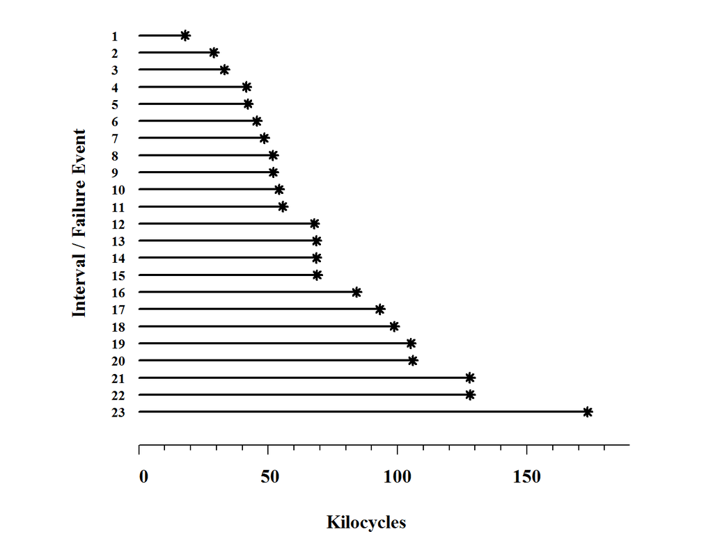

# 7.6.4 - CI for $\hat{\theta}_{_{MLE}}$ with complete data or Type II censoring

# 7.7 - Data analysis with no failures

[figure not shown]